# DEEPIKA_RATHORE_EDA & FE - Graded Internal Microproject

```python
import pyforest
```

```python
import pandas as pd
```

```python
import warnings
warnings.filterwarnings('ignore')
```

```python
path=pd.read_excel('car_loan.xlsx',sheet_name=[0,1])
#path=pd.read_excel('loan_data.xlsx', sheet_name=[0,1])
```

```python
x=path[0]
```

```python
y=path[1]
```

```python
x
```

|  | cust.ID | Amount.Requested for loan | Amount.Funded.By.Investors to bank | Interest.Rate | Loan duration |
| --- | --- | --- | --- | --- | --- |
| 0 | 84563.0 | 8000 | 8000 | 7.62# | 36 months |
| 1 | 78765.0 | 9000 | 9000 | 10.16# | 36 months |
| 2 | 24590.0 | 13000 | 12975 | 9.99# | 60 months |
| 3 | 9061.0 | 10000 | 10000 | 14.22# | 36 months |
| 4 | 47011.0 | 3600 | 3600 | 13.67# | 36 months |
| ... | ... | ... | ... | ... | ... |
| 2181 | 101795.0 | 10000 | 550 | 10.59# | 36 months |
| 2182 | 84805.0 | 13225 | 13225 | 15.31# | 36 months |
| 2183 | 101548.0 | 10000 | 525 | 14.7# | 36 months |
| 2184 | 3209.0 | 12000 | 11725 | 9.63# | 36 months |
| 2185 | 42828.0 | 16000 | 16000 | 8.9# | 36 months |

2186 rows × 5 columns

```python
y
```

|  | cust.ID | Family_incomeIncome | credit_score | Employment.Length | owning a two wheeler |
| --- | --- | --- | --- | --- | --- |
| 0 | 84563.0 | 3500 | 765-769 | NaN | yes |
| 1 | 78765.0 | 5166.67 | 710-714 | 10 + years | no |
| 2 | 24590.0 | 10500 | 800-804 | 10+ years | yes |
| 3 | 9061.0 | 2541.67 | 680-684 | 8 years | no |
| 4 | 47011.0 | 5113 | 690-694 | NaN | yes |
| ... | ... | ... | ... | ... | ... |
| 2181 | 101795.0 | 2083.33 | 685-689 | < 1 year | no |
| 2182 | 84805.0 | 5833.33 | 680-684 | 10+ years | yes |
| 2183 | 101548.0 | 5416.67 | 645-649 | < 1 year | no |
| 2184 | 3209.0 | 3000 | 750-754 | < 1 year | yes |
| 2185 | 42828.0 | 5750 | 725-729 | 6 years | no |

2186 rows × 5 columns

```python
df=pd.read_csv('age_band.csv')
df
```

|  | cust.ID\tage-band \tDebt.To.Income.Ratio | Unnamed: 1 |
| --- | --- | --- |
| 0 | 84563\t25-39\t0! | NaN |
| 1 | 78765\t25-40\t13.76! | NaN |
| 2 | 24590\t25-41\t8.77! | NaN |
| 3 | 9061\t25-42\t12.24! | NaN |
| 4 | 47011\t25-43\t16.41! | NaN |
| ... | ... | ... |
| 2181 | 101795\t45-55\t10.22! | NaN |
| 2182 | 84805\t45-55\t27.07! | NaN |
| 2183 | 101548\t45-55\t6.37! | NaN |
| 2184 | 3209\t45-55\t15! | NaN |
| 2185 | 42828\t45-55\t14.85! | NaN |

2186 rows × 2 columns

```python
try:
    # Split the column into three separate columns
    df[['cust.ID', 'age-band', 'Debt.To.Income.Ratio']] = df['cust.ID\tage-band \tDebt.To.Income.Ratio'].str.split('\t', expand=True)
except ValueError as e:
    print("Error:", e)
```

```python
df['Debt.To.Income.Ratio'] = df['Debt.To.Income.Ratio'].str.replace('!', '')
df
```

|  | cust.ID\tage-band \tDebt.To.Income.Ratio | Unnamed: 1 | cust.ID | age-band | Debt.To.Income.Ratio |
| --- | --- | --- | --- | --- | --- |
| 0 | 84563\t25-39\t0! | NaN | 84563 | 25-39 | 0 |
| 1 | 78765\t25-40\t13.76! | NaN | 78765 | 25-40 | 13.76 |
| 2 | 24590\t25-41\t8.77! | NaN | 24590 | 25-41 | 8.77 |
| 3 | 9061\t25-42\t12.24! | NaN | 9061 | 25-42 | 12.24 |
| 4 | 47011\t25-43\t16.41! | NaN | 47011 | 25-43 | 16.41 |
| ... | ... | ... | ... | ... | ... |
| 2181 | 101795\t45-55\t10.22! | NaN | 101795 | 45-55 | 10.22 |
| 2182 | 84805\t45-55\t27.07! | NaN | 84805 | 45-55 | 27.07 |
| 2183 | 101548\t45-55\t6.37! | NaN | 101548 | 45-55 | 6.37 |
| 2184 | 3209\t45-55\t15! | NaN | 3209 | 45-55 | 15 |
| 2185 | 42828\t45-55\t14.85! | NaN | 42828 | 45-55 | 14.85 |

2186 rows × 5 columns

```python
z=df
z
```

|  | cust.ID\tage-band \tDebt.To.Income.Ratio | Unnamed: 1 | cust.ID | age-band | Debt.To.Income.Ratio |
| --- | --- | --- | --- | --- | --- |
| 0 | 84563\t25-39\t0! | NaN | 84563 | 25-39 | 0 |
| 1 | 78765\t25-40\t13.76! | NaN | 78765 | 25-40 | 13.76 |
| 2 | 24590\t25-41\t8.77! | NaN | 24590 | 25-41 | 8.77 |
| 3 | 9061\t25-42\t12.24! | NaN | 9061 | 25-42 | 12.24 |
| 4 | 47011\t25-43\t16.41! | NaN | 47011 | 25-43 | 16.41 |
| ... | ... | ... | ... | ... | ... |
| 2181 | 101795\t45-55\t10.22! | NaN | 101795 | 45-55 | 10.22 |
| 2182 | 84805\t45-55\t27.07! | NaN | 84805 | 45-55 | 27.07 |
| 2183 | 101548\t45-55\t6.37! | NaN | 101548 | 45-55 | 6.37 |
| 2184 | 3209\t45-55\t15! | NaN | 3209 | 45-55 | 15 |
| 2185 | 42828\t45-55\t14.85! | NaN | 42828 | 45-55 | 14.85 |

2186 rows × 5 columns

```python
df=pd.concat([x,y,z],axis=1)
df
```

|  | cust.ID | Amount.Requested for loan | Amount.Funded.By.Investors to bank | Interest.Rate | Loan duration | cust.ID | Family_incomeIncome | credit_score | Employment.Length | owning a two wheeler | cust.ID\tage-band \tDebt.To.Income.Ratio | Unnamed: 1 | cust.ID | age-band | Debt.To.Income.Ratio |
| --- | --- | --- | --- | --- | --- | --- | --- | --- | --- | --- | --- | --- | --- | --- | --- |
| 0 | 84563.0 | 8000 | 8000 | 7.62# | 36 months | 84563.0 | 3500 | 765-769 | NaN | yes | 84563\t25-39\t0! | NaN | 84563 | 25-39 | 0 |
| 1 | 78765.0 | 9000 | 9000 | 10.16# | 36 months | 78765.0 | 5166.67 | 710-714 | 10 + years | no | 78765\t25-40\t13.76! | NaN | 78765 | 25-40 | 13.76 |
| 2 | 24590.0 | 13000 | 12975 | 9.99# | 60 months | 24590.0 | 10500 | 800-804 | 10+ years | yes | 24590\t25-41\t8.77! | NaN | 24590 | 25-41 | 8.77 |
| 3 | 9061.0 | 10000 | 10000 | 14.22# | 36 months | 9061.0 | 2541.67 | 680-684 | 8 years | no | 9061\t25-42\t12.24! | NaN | 9061 | 25-42 | 12.24 |
| 4 | 47011.0 | 3600 | 3600 | 13.67# | 36 months | 47011.0 | 5113 | 690-694 | NaN | yes | 47011\t25-43\t16.41! | NaN | 47011 | 25-43 | 16.41 |
| ... | ... | ... | ... | ... | ... | ... | ... | ... | ... | ... | ... | ... | ... | ... | ... |
| 2181 | 101795.0 | 10000 | 550 | 10.59# | 36 months | 101795.0 | 2083.33 | 685-689 | < 1 year | no | 101795\t45-55\t10.22! | NaN | 101795 | 45-55 | 10.22 |
| 2182 | 84805.0 | 13225 | 13225 | 15.31# | 36 months | 84805.0 | 5833.33 | 680-684 | 10+ years | yes | 84805\t45-55\t27.07! | NaN | 84805 | 45-55 | 27.07 |
| 2183 | 101548.0 | 10000 | 525 | 14.7# | 36 months | 101548.0 | 5416.67 | 645-649 | < 1 year | no | 101548\t45-55\t6.37! | NaN | 101548 | 45-55 | 6.37 |
| 2184 | 3209.0 | 12000 | 11725 | 9.63# | 36 months | 3209.0 | 3000 | 750-754 | < 1 year | yes | 3209\t45-55\t15! | NaN | 3209 | 45-55 | 15 |
| 2185 | 42828.0 | 16000 | 16000 | 8.9# | 36 months | 42828.0 | 5750 | 725-729 | 6 years | no | 42828\t45-55\t14.85! | NaN | 42828 | 45-55 | 14.85 |

2186 rows × 15 columns

PART - I 1) I) Check for duplicate columns & remove them

```python
df=df.loc[:,~df.columns.duplicated()]
```

```python
df
```

|  | cust.ID | Amount.Requested for loan | Amount.Funded.By.Investors to bank | Interest.Rate | Loan duration | Family_incomeIncome | credit_score | Employment.Length | owning a two wheeler | cust.ID\tage-band \tDebt.To.Income.Ratio | Unnamed: 1 | age-band | Debt.To.Income.Ratio |
| --- | --- | --- | --- | --- | --- | --- | --- | --- | --- | --- | --- | --- | --- |
| 0 | 84563.0 | 8000 | 8000 | 7.62# | 36 months | 3500 | 765-769 | NaN | yes | 84563\t25-39\t0! | NaN | 25-39 | 0 |
| 1 | 78765.0 | 9000 | 9000 | 10.16# | 36 months | 5166.67 | 710-714 | 10 + years | no | 78765\t25-40\t13.76! | NaN | 25-40 | 13.76 |
| 2 | 24590.0 | 13000 | 12975 | 9.99# | 60 months | 10500 | 800-804 | 10+ years | yes | 24590\t25-41\t8.77! | NaN | 25-41 | 8.77 |
| 3 | 9061.0 | 10000 | 10000 | 14.22# | 36 months | 2541.67 | 680-684 | 8 years | no | 9061\t25-42\t12.24! | NaN | 25-42 | 12.24 |
| 4 | 47011.0 | 3600 | 3600 | 13.67# | 36 months | 5113 | 690-694 | NaN | yes | 47011\t25-43\t16.41! | NaN | 25-43 | 16.41 |
| ... | ... | ... | ... | ... | ... | ... | ... | ... | ... | ... | ... | ... | ... |
| 2181 | 101795.0 | 10000 | 550 | 10.59# | 36 months | 2083.33 | 685-689 | < 1 year | no | 101795\t45-55\t10.22! | NaN | 45-55 | 10.22 |
| 2182 | 84805.0 | 13225 | 13225 | 15.31# | 36 months | 5833.33 | 680-684 | 10+ years | yes | 84805\t45-55\t27.07! | NaN | 45-55 | 27.07 |
| 2183 | 101548.0 | 10000 | 525 | 14.7# | 36 months | 5416.67 | 645-649 | < 1 year | no | 101548\t45-55\t6.37! | NaN | 45-55 | 6.37 |
| 2184 | 3209.0 | 12000 | 11725 | 9.63# | 36 months | 3000 | 750-754 | < 1 year | yes | 3209\t45-55\t15! | NaN | 45-55 | 15 |
| 2185 | 42828.0 | 16000 | 16000 | 8.9# | 36 months | 5750 | 725-729 | 6 years | no | 42828\t45-55\t14.85! | NaN | 45-55 | 14.85 |

2186 rows × 13 columns

II) If you want you can drop column/columns (Mention the reason for the same for removing or not)

```python
 #  'Amount.Funded.By.Investors to bank' ,'cust.ID\tage-band \tDebt.To.Income.Ratio','Unnamed: 1': DROP
 # note- no need of this data
```

```python
df.drop(['Amount.Funded.By.Investors to bank','cust.ID\tage-band \tDebt.To.Income.Ratio','Unnamed: 1'], axis=1, inplace=True)
df
```

|  | cust.ID | Amount.Requested for loan | Interest.Rate | Loan duration | Family_incomeIncome | credit_score | Employment.Length | owning a two wheeler | age-band | Debt.To.Income.Ratio |
| --- | --- | --- | --- | --- | --- | --- | --- | --- | --- | --- |
| 0 | 84563.0 | 8000 | 7.62# | 36 months | 3500 | 765-769 | NaN | yes | 25-39 | 0 |
| 1 | 78765.0 | 9000 | 10.16# | 36 months | 5166.67 | 710-714 | 10 + years | no | 25-40 | 13.76 |
| 2 | 24590.0 | 13000 | 9.99# | 60 months | 10500 | 800-804 | 10+ years | yes | 25-41 | 8.77 |
| 3 | 9061.0 | 10000 | 14.22# | 36 months | 2541.67 | 680-684 | 8 years | no | 25-42 | 12.24 |
| 4 | 47011.0 | 3600 | 13.67# | 36 months | 5113 | 690-694 | NaN | yes | 25-43 | 16.41 |
| ... | ... | ... | ... | ... | ... | ... | ... | ... | ... | ... |
| 2181 | 101795.0 | 10000 | 10.59# | 36 months | 2083.33 | 685-689 | < 1 year | no | 45-55 | 10.22 |
| 2182 | 84805.0 | 13225 | 15.31# | 36 months | 5833.33 | 680-684 | 10+ years | yes | 45-55 | 27.07 |
| 2183 | 101548.0 | 10000 | 14.7# | 36 months | 5416.67 | 645-649 | < 1 year | no | 45-55 | 6.37 |
| 2184 | 3209.0 | 12000 | 9.63# | 36 months | 3000 | 750-754 | < 1 year | yes | 45-55 | 15 |
| 2185 | 42828.0 | 16000 | 8.9# | 36 months | 5750 | 725-729 | 6 years | no | 45-55 | 14.85 |

2186 rows × 10 columns

PART - I 2. Using seaborn/matplotlib give any two visuals and mention the insights.

```python
import matplotlib.pyplot as plt
import seaborn as sn
```

```python
df.columns
```

```
Index(['cust.ID', 'Amount.Requested for loan', 'Interest.Rate',
       'Loan duration', 'Family_incomeIncome', 'credit_score',
       'Employment.Length', 'owning a two wheeler', 'age-band',
       'Debt.To.Income.Ratio'],
      dtype='object')
```

```python
df.dtypes
```

```
cust.ID                      float64
Amount.Requested for loan     object
Interest.Rate                 object
Loan duration                 object
Family_incomeIncome           object
credit_score                  object
Employment.Length             object
owning a two wheeler          object
age-band                      object
Debt.To.Income.Ratio          object
dtype: object
```

[figure not shown]

```python
#  heatmap before cleaning the data
selected_columns = ['cust.ID', 'Amount.Requested for loan', 'Interest.Rate',
       'Loan duration', 'Family_incomeIncome', 'credit_score',
       'Employment.Length', 'owning a two wheeler', 'age-band',
       'Debt.To.Income.Ratio']


selected_df = df[selected_columns]


correlation_matrix = selected_df.corr()


plt.figure(figsize=(5, 8))
sns.heatmap(correlation_matrix, annot=True, cmap='coolwarm', linewidths=.5)
plt.title('Correlation Heatmap of Selected Columns')
plt.show()
```

Insights:

1) This heatmap visually represents the correlation between the selected numerical columns. 2) It helps to identify strong positive/negative relationships between variables.

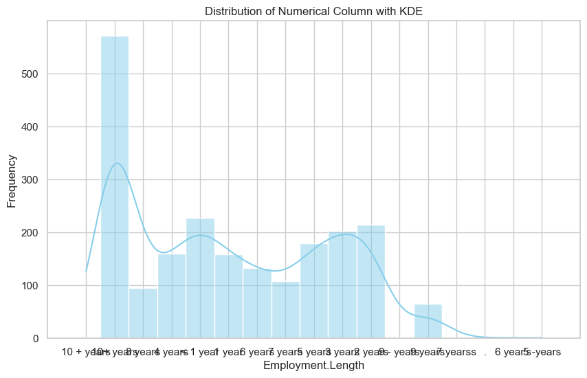

```python
# histplot before cleaning the data
import seaborn as sns
import matplotlib.pyplot as plt

# Assuming 'df' is your DataFrame and 'numerical_column' is the numerical column you want to visualize
plt.figure(figsize=(10, 6))
sns.histplot(df['Employment.Length'], kde=True, color='skyblue')
plt.title('Distribution of Numerical Column with KDE')
plt.xlabel('Employment.Length')
plt.ylabel('Frequency')
plt.show()
```

Insights:

1) Distribution Shape: The histogram shows the shape of the distribution of the numerical column. 2) It helps to identify whether the data is skewed or symmetric. 3) Central Tendency: The central tendency of the data, such as mean and median, can be observed from the histogram.

```python
#'Interest.Rate': removing #
```

```python
df['Interest.Rate'] = df['Interest.Rate'].astype(str)

for col in ['Interest.Rate']:
    df[col]=df[col].str.replace('#','')
```

```python
df
```

[output not shown]

2186 rows × 10 columns

```python
df.dtypes
```

[output not shown]

```python
df
```

[output not shown]

2186 rows × 8 columns

```python
# Amount.Requested for loan,Interest.Rate ,Family_incomeIncome,Employment.Length :- convert to numeric
for col in ['Amount.Requested for loan','Interest.Rate','Family_incomeIncome']:
    df[col]=pd.to_numeric(df[col], errors='coerce')
```

```python
df.dtypes
```

```
cust.ID                      float64
Amount.Requested for loan    float64
Interest.Rate                float64
Loan duration                 object
Family_incomeIncome          float64
credit_score                  object
Employment.Length             object
owning a two wheeler          object
age-band                      object
Debt.To.Income.Ratio          object
dtype: object
```

```python
df['Employment.Length'].value_counts().to_frame()
```

|  | Employment.Length |
| --- | --- |
| 10+ years | 571 |
| < 1 year | 227 |
| 2 years | 214 |
| 3 years | 203 |
| 5 years | 179 |
| 4 years | 160 |
| 1 year | 159 |
| 6 years | 132 |
| 7 years | 108 |
| 8 years | 95 |
| 9 years | 65 |
| . | 1 |
| 6 year's | 1 |
| 10 + years | 1 |
| 7 yearss | 1 |
| 9 - years | 1 |
| 5 -years | 1 |

```python
df.dtypes
```

[output not shown]

PART-I 3) Clean the data (string cleaning)

```python
import pandas as pd




special_characters = r"[!@#$%^&*(),.?\":{}|<>]"


df['Employment.Length'] = df['Employment.Length'].str.replace(special_characters, '')
df['owning a two wheeler'] = df['owning a two wheeler'].str.replace(special_characters, '')


df
```

|  | cust.ID | Amount.Requested for loan | Interest.Rate | Loan duration | Family_incomeIncome | credit_score | Employment.Length | owning a two wheeler | age-band | Debt.To.Income.Ratio |
| --- | --- | --- | --- | --- | --- | --- | --- | --- | --- | --- |
| 0 | 84563.0 | 8000.0 | NaN | 36 months | 3500.00 | 765-769 | NaN | yes | 25-39 | 0 |
| 1 | 78765.0 | 9000.0 | NaN | 36 months | 5166.67 | 710-714 | 10 + years | no | 25-40 | 13.76 |
| 2 | 24590.0 | 13000.0 | NaN | 60 months | 10500.00 | 800-804 | 10+ years | yes | 25-41 | 8.77 |
| 3 | 9061.0 | 10000.0 | NaN | 36 months | 2541.67 | 680-684 | 8 years | no | 25-42 | 12.24 |
| 4 | 47011.0 | 3600.0 | NaN | 36 months | 5113.00 | 690-694 | NaN | yes | 25-43 | 16.41 |
| ... | ... | ... | ... | ... | ... | ... | ... | ... | ... | ... |
| 2181 | 101795.0 | 10000.0 | NaN | 36 months | 2083.33 | 685-689 | 1 year | no | 45-55 | 10.22 |
| 2182 | 84805.0 | 13225.0 | NaN | 36 months | 5833.33 | 680-684 | 10+ years | yes | 45-55 | 27.07 |
| 2183 | 101548.0 | 10000.0 | NaN | 36 months | 5416.67 | 645-649 | 1 year | no | 45-55 | 6.37 |
| 2184 | 3209.0 | 12000.0 | NaN | 36 months | 3000.00 | 750-754 | 1 year | yes | 45-55 | 15 |
| 2185 | 42828.0 | 16000.0 | NaN | 36 months | 5750.00 | 725-729 | 6 years | no | 45-55 | 14.85 |

2186 rows × 10 columns

```python
df['Employment.Length']=df['Employment.Length'].str.replace('years','')
df['Employment.Length']=df['Employment.Length'].str.replace('year','')
df['Employment.Length']=df['Employment.Length'].str.replace('<','')
df['Employment.Length']=df['Employment.Length'].str.replace('+','')
df['Employment.Length']=df['Employment.Length'].str.replace('s','')
df['Employment.Length']=df['Employment.Length'].str.replace('-','')
df['Employment.Length']=df['Employment.Length'].str.replace('s','')
df['Employment.Length']=df['Employment.Length'].str.replace("'",'')
df['Employment.Length']=df['Employment.Length'].str.replace('.','nan')
```

```python
# convert data from object to numeric
for col in ['cust.ID', 'Amount.Requested for loan', 'Interest.Rate',
       'Family_incomeIncome',
       'Employment.Length',
       'Debt.To.Income.Ratio']:
    df[col]=pd.to_numeric(df[col], errors='coerce')
```

```python
df.dtypes
```

```
cust.ID                      float64
Amount.Requested for loan    float64
Interest.Rate                float64
Loan duration                 object
Family_incomeIncome          float64
credit_score                  object
Employment.Length            float64
owning a two wheeler          object
age-band                      object
Debt.To.Income.Ratio         float64
dtype: object
```

```python
df
```

|  | cust.ID | Amount.Requested for loan | Interest.Rate | Loan duration | Family_incomeIncome | credit_score | Employment.Length | owning a two wheeler | age-band | Debt.To.Income.Ratio |
| --- | --- | --- | --- | --- | --- | --- | --- | --- | --- | --- |
| 0 | 84563.0 | 8000.0 | NaN | 36 months | 3500.00 | 765-769 | NaN | yes | 25-39 | 0.00 |
| 1 | 78765.0 | 9000.0 | NaN | 36 months | 5166.67 | 710-714 | 10.0 | no | 25-40 | 13.76 |
| 2 | 24590.0 | 13000.0 | NaN | 60 months | 10500.00 | 800-804 | 10.0 | yes | 25-41 | 8.77 |
| 3 | 9061.0 | 10000.0 | NaN | 36 months | 2541.67 | 680-684 | 8.0 | no | 25-42 | 12.24 |
| 4 | 47011.0 | 3600.0 | NaN | 36 months | 5113.00 | 690-694 | NaN | yes | 25-43 | 16.41 |
| ... | ... | ... | ... | ... | ... | ... | ... | ... | ... | ... |
| 2181 | 101795.0 | 10000.0 | NaN | 36 months | 2083.33 | 685-689 | 1.0 | no | 45-55 | 10.22 |
| 2182 | 84805.0 | 13225.0 | NaN | 36 months | 5833.33 | 680-684 | 10.0 | yes | 45-55 | 27.07 |
| 2183 | 101548.0 | 10000.0 | NaN | 36 months | 5416.67 | 645-649 | 1.0 | no | 45-55 | 6.37 |
| 2184 | 3209.0 | 12000.0 | NaN | 36 months | 3000.00 | 750-754 | 1.0 | yes | 45-55 | 15.00 |
| 2185 | 42828.0 | 16000.0 | NaN | 36 months | 5750.00 | 725-729 | 6.0 | no | 45-55 | 14.85 |

2186 rows × 10 columns

PART-1 4) 4. Check for outliers present in the data, decide whether you want to remove them or not. Justify the same

```python
from scipy import stats

# Calculate z-scores for the numerical column
z_scores1 = stats.zscore(df['Amount.Requested for loan'])
z_scores2 = stats.zscore(df['cust.ID'])
z_scores3 = stats.zscore(df['Interest.Rate'])
z_scores4 = stats.zscore(df['Family_incomeIncome'])

# Define a threshold for identifying outliers
threshold = 3

# Identify outliers based on the threshold
outliers1 = (z_scores1 > threshold) | (z_scores1 < -threshold)
outliers2 = (z_scores2 > threshold) | (z_scores2 < -threshold)
outliers3 = (z_scores3 > threshold) | (z_scores3 < -threshold)
outliers4 = (z_scores4 > threshold) | (z_scores4 < -threshold)



# Count the number of outliers
num_outliers1 = sum(outliers1)
print("Number of outliers:", num_outliers)

num_outliers2 = sum(outliers2)
print("Number of outliers:", num_outliers)

num_outliers3 = sum(outliers3)
print("Number of outliers:", num_outliers)

num_outliers4 = sum(outliers4)
print("Number of outliers:", num_outliers)
```

[output not shown]

remove outliers or not depends on various factors and Here are some points to consider: 1) Impact on Analysis 2) Data Integrity 3) Sample Size 4) Model Performance 5) Context and Domain Knowledge

```python
PART-II
1) How much missing data is there in the dataset? What's the impact of missing data on analysis and modelling?
```

```python
# Check for missing values
print("Missing values:")
print(df.isnull().sum())
```

[output not shown]

### What's the impact of missing data on analysis and modelling?

missing data can have a detrimental impact on the validity, reliability, and interpretability of analysis results and predictive models. Proper handling of missing data, through techniques such as imputation or careful consideration of missing data mechanisms, is essential to mitigate these effects and ensure the integrity of the analysis.

PART-II 2) Do the missing value imputation for numerical & categorical data

```python
# Display the data types of each column
print(df.dtypes)

# Numerical Data Imputation
numerical_columns = ['cust.ID', 'Amount.Requested for loan', 'Interest.Rate', 'Family_incomeIncome']
for column in numerical_columns:
    if df[column].dtype == 'float64':
        mean_value = df[column].mean()
        df[column].fillna(mean_value, inplace=True)

# Categorical Data Imputation
categorical_columns = ['Loan duration', 'credit_score', 'Employment.Length', 'owning a two wheeler']
for column in categorical_columns:
    if df[column].dtype == 'object':
        mode_value = df[column].mode()[0]
        df[column].fillna(mode_value, inplace=True)

# Display the DataFrame after imputation
print(df.head())
```

[output not shown]

```python
PART-II
3) Which variables in the dataset require one-hot encoding using pd.getdummies?
Treat them accordingly. What is the purpose of using one-hot encoding for these variables?
```

```python
In our dataset, the following variables may require one-hot encoding:
'Loan duration'
'credit_score'
'Employment.Length'
'owning a two wheeler'
```

```python
# Apply one-hot encoding for categorical variables
categorical_columns = ['Loan duration', 'credit_score', 'Employment.Length', 'owning a two wheeler']
df_encoded = pd.get_dummies(df, columns=categorical_columns)

# Display the DataFrame after one-hot encoding
print(df_encoded.head())
```

```
   cust.ID  Amount.Requested for loan  Interest.Rate  Family_incomeIncome  \
0  84563.0                     8000.0            NaN              3500.00
1  78765.0                     9000.0            NaN              5166.67
2  24590.0                    13000.0            NaN             10500.00
3   9061.0                    10000.0            NaN              2541.67
4  47011.0                     3600.0            NaN              5113.00

   Loan duration_.  Loan duration_36 months  Loan duration_60 months  \
0                0                        1                        0
1                0                        1                        0
2                0                        0                        1
3                0                        1                        0
4                0                        1                        0

   Loan duration_>= 36 months  credit_score_640-644  credit_score_645-649  \
```

[output cut: 35 more lines]

The purpose of using one-hot encoding for categorical variables is to convert categorical data into a format that can be provided to machine learning algorithms. One-hot encoding transforms categorical variables into binary vectors, where each category becomes a binary column (0 or 1), indicating the presence or absence of that category for each observation.

Overall, one-hot encoding is a widely used technique for preprocessing categorical variables, enabling better model performance and interpretability in machine learning tasks.

```python
PART-II
4) Is there a correlation between two numerical variables? Is it positive or negative?
```

```python
correlation = df['Amount.Requested for loan'].corr(df['Family_incomeIncome'])

# Print the correlation coefficient
print("correlation coefficient:", correlation)

# Determine if the correlation is positive or negative
if correlation > 0:
    print("There is a positive correlation between the variables.")
elif correlation < 0:
    print("There is a negative correlation between the variables.")
else:
    print("There is no linear correlation between the variables.")
```

```
correlation coefficient: 0.29404580264848335
There is a positive correlation between the variables.
```

```python
df
```

[output not shown]

2186 rows × 10 columns

PART - I

1. Using seaborn/matplotlib give any two visuals and mention the insights.

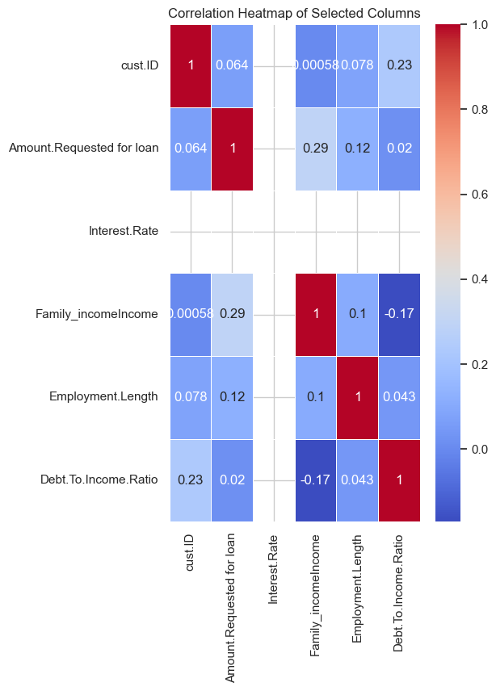

```python
#  heatmap after cleaning the data
selected_columns = ['cust.ID', 'Amount.Requested for loan', 'Interest.Rate',
       'Loan duration', 'Family_incomeIncome', 'credit_score',
       'Employment.Length', 'owning a two wheeler', 'age-band',
       'Debt.To.Income.Ratio']


selected_df = df[selected_columns]


correlation_matrix = selected_df.corr()


plt.figure(figsize=(5, 8))
sns.heatmap(correlation_matrix, annot=True, cmap='coolwarm', linewidths=.5)
plt.title('Correlation Heatmap of Selected Columns')
plt.show()
```

```python
Insights:

1) This heatmap visually represents the correlation between the selected numerical columns.
2) It helps to identify strong positive/negative relationships between variables.
```

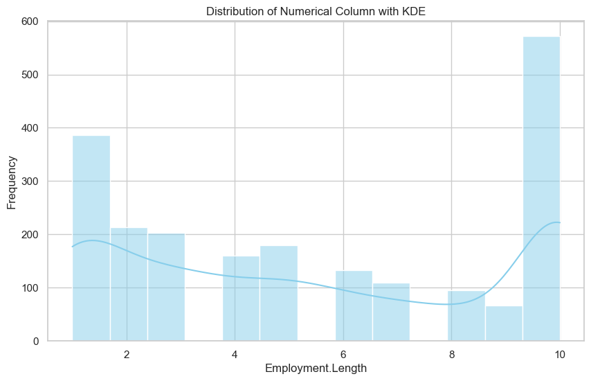

```python
# histplot after cleaning the data
import seaborn as sns
import matplotlib.pyplot as plt

# Assuming 'df' is your DataFrame and 'numerical_column' is the numerical column you want to visualize
plt.figure(figsize=(10, 6))
sns.histplot(df['Employment.Length'], kde=True, color='skyblue')
plt.title('Distribution of Numerical Column with KDE')
plt.xlabel('Employment.Length')
plt.ylabel('Frequency')
plt.show()
```

Insights:

1) Distribution Shape: The histogram shows the shape of the distribution of the numerical column. 2) It helps to identify whether the data is skewed or symmetric. 3) Central Tendency: The central tendency of the data, such as mean and median, can be observed from the histogram.